# Exercise Sheet 3

1. The following two-dimensional data set is given. Perform a $K$-means Clustering with $K=3$ using the Euclidean distance. Use the first three points as initial centroids. For each algorithm iteration, specify the distances between centroids and all points and calculate the changed centroids after each reassignment of the points.

| <nbsp;> | p1 | p2 | p3 | p4 | p5 | p6 | p7 | p8 | p9 | p10 | p11 | p12 |
| --- | --- | --- | --- | --- | --- | --- | --- | --- | --- | --- | --- | --- |
| x | 2.0 | 2.0 | 2.0 | 2.5 | 2.5 | 3.0 | 4.0 | 4.0 | 4.5 | 4.5 | 4.5 | 4.5 |
| y | 1.0 | 1.5 | 2.0 | 1.0 | 2.0 | 4.0 | 1.0 | 2.5 | 1.0 | 1.5 | 2.5 | 3.0 |

```r
# dat <- tibble(
#   x = c(2.0, 2.0, 2.0, 2.5, 2.5, 3.0, 4.0, 4.0, 4.5, 4.5, 4.5 , 4.5),
#   y = c(1.0, 1.5, 2.0, 1.0, 2.0, 4.0, 1.0, 2.5, 1.0, 1.5, 2.5 , 3.0)
# )

# Solution of task 1...

x <- c(2.0,2.0,2.0,2.5,2.5,3.0,4.0,4.0,4.5,4.5,4.5,4.5)
y <- c(1.0,1.5,2.0,1.0,2.0,4.0,1.0,2.5,1.0,1.5,2.5,3.0)
index <- c("p1","p2","p3","p4","p5","p6","p7","p8","p9","p10","p11","p12")

DF <- data.frame(index, x, y, stringsAsFactors=FALSE)
PreviousCentroids <- (DF[c(1,2,3),c("index","x","y")])

print(PreviousCentroids)
```

```
##   index x   y
## 1    p1 2 1.0
## 2    p2 2 1.5
## 3    p3 2 2.0
```

```r
iter <-1
repeat{

  CurrentCentroids <- PreviousCentroids
  Distance <- apply(CurrentCentroids,1,function(CurrentCentroids)
    (apply(DF,1,function(DF,CurrentCentroids)
      dist(rbind(DF,CurrentCentroids)),CurrentCentroids)))

Distance <- data.frame(Distance)

cols <- c("p1","p2","p3")
colnames(Distance) <- cols

Distance$Clusters <- colnames(Distance)[apply(Distance,1,which.min)]
Distance$index <-index
DF2 <- merge(DF, Distance, by="index")
cat("After iteration ",iter)
cat(" \n")
cat("Distance Matrix and Cluster Assignment")
cat(" \n")
print(DF2)
cat(" \n")

DF2 <- DF2 %>%
  select(index,x, y, p1, p2, p3, Clusters) %>% group_by(Clusters)

PreviousCentroids <-  DF2 %>%  summarise(x = mean(x),
                                       y = mean(y))
cat("Changed Centroids")
print(PreviousCentroids)
cat(" \n")
iter <- iter +1

if (all(CurrentCentroids == PreviousCentroids)) {
  break

}
}
```

```
## After iteration  1
## Distance Matrix and Cluster Assignment
##    index   x   y        p1        p2        p3 Clusters
## 1     p1 2.0 1.0 0.0000000 0.6123724 1.2247449       p1
## 2    p10 4.5 1.5 3.1224990 3.0618622 3.1224990       p2
## 3    p11 4.5 2.5 3.5707142 3.2977265 3.1224990       p3
## 4    p12 4.5 3.0 3.9210968 3.5707142 3.2977265       p3
## 5     p2 2.0 1.5 0.6123724 0.0000000 0.6123724       p2
## 6     p3 2.0 2.0 1.2247449 0.6123724 0.0000000       p3
## 7     p4 2.5 1.0 0.6123724 0.8660254 1.3693064       p1
## 8     p5 2.5 2.0 1.3693064 0.8660254 0.6123724       p3
## 9     p6 3.0 4.0 3.8729833 3.2977265 2.7386128       p3
## 10    p7 4.0 1.0 2.4494897 2.5248762 2.7386128       p1
## 11    p8 4.0 2.5 3.0618622 2.7386128 2.5248762       p3
## 12    p9 4.5 1.0 3.0618622 3.1224990 3.2977265       p1
##
## Changed Centroids# A tibble: 3 x 3
##   Clusters     x     y
##   <chr>    <dbl> <dbl>
## 1 p1        3.25  1
## 2 p2        3.25  1.5
## 3 p3        3.42  2.67
##
## After iteration  2
## Distance Matrix and Cluster Assignment
##    index   x   y        p1       p2        p3 Clusters
## 1     p1 2.0 1.0 1.5309311 1.648863 2.6790085       p1
## 2    p10 4.5 1.5 1.6488632 1.530931 1.9498932       p2
## 3    p11 4.5 2.5 2.3913908 1.960548 1.3424166       p3
## 4    p12 4.5 3.0 2.8885550 2.391391 1.3881938       p3
## 5     p2 2.0 1.5 1.6488632 1.530931 2.2476846       p2
## 6     p3 2.0 2.0 1.9605484 1.648863 1.9175728       p2
## 7     p4 2.5 1.0 0.9185587 1.103970 2.3296107       p1
## 8     p5 2.5 2.0 1.5309311 1.103970 1.3881948       p2
## 9     p6 3.0 4.0 3.6869703 3.077133 1.7108718       p3
## 10    p7 4.0 1.0 0.9185587 1.103970 2.1626568       p1
## 11    p8 4.0 2.5 2.0539596 1.530931 0.7430228       p3
## 12    p9 4.5 1.0 1.5309311 1.648863 2.4345603       p1
##
## Changed Centroids# A tibble: 3 x 3
```

[output cut: 60 more lines]

```
## 6     p3 2.0 2.0 3.0345231 0.6595453 2.7386128       p2
## 7     p4 2.5 1.0 2.2546245 0.7141428 3.0618622       p2
## 8     p5 2.5 2.0 2.4664409 0.7141428 2.2079402       p2
## 9     p6 3.0 4.0 3.8351440 3.2148095 1.7320508       p3
## 10    p7 4.0 1.0 0.4564353 2.2880122 2.4494897       p1
## 11    p8 4.0 2.5 1.6832503 2.5219040 0.6123724       p3
## 12    p9 4.5 1.0 0.2886757 2.8827071 2.5248762       p1
##
## Changed Centroids# A tibble: 3 x 3
##   Clusters     x     y
##   <chr>    <dbl> <dbl>
## 1 p1        4.33  1.17
## 2 p2        2.2   1.5
## 3 p3        4     3
##
```

2. A school would like to group its pupils according to their performance at two intermediate examinations. It is assumed that there are at least 2 clusters of pupils. Load the file `clustering-student-mat.csv`. The file contains for each of the two exams the number of points scored for a total of 395 students.  
   Perform a $K$-means-Clustering for each $k\in \{2,3,\ldots,8\}$. Display the cluster assignments of the points in a scatter plot.

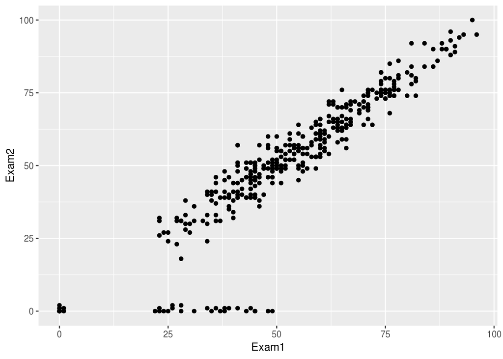

```r
# Solution of task 2...

 DF <- read_csv(str_c(dirname(getwd()), "/Exercise3/clustering-student-mat.csv"))
#DF <- read.csv("clustering-student-mat.csv")
ggplot(DF, aes(x = Exam1, y = Exam2)) +
  geom_point()
```

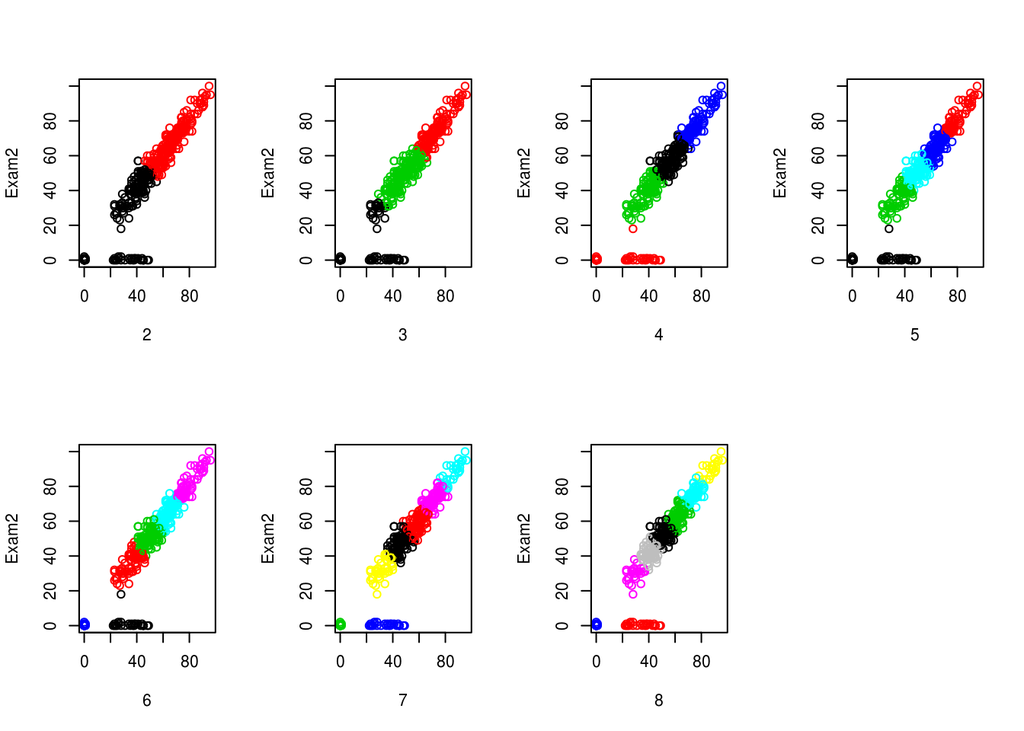

```r
iter <- 1
plotlist = list()
par(mfrow=c(2,4))
for(i in 2:8) {
      K <- kmeans(DF, centers= i , nstart = 25)
      plot(DF,col=K$cluster,(main= i))
}
```

3. For the clustering in task 2, use the silhouette coefficient to find the optimal value for the number of clusters $K$. Evaluate the result for the representativeness of the centroids with respect to their cluster.

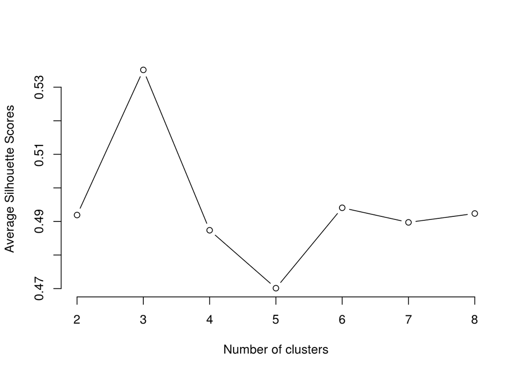

```r
# Solution of task 3...

silhouette_score <- function(k){
  km <- kmeans(DF, centers = k, nstart=25)
  ss <- silhouette(km$cluster, dist(DF))
  mean(ss[, 3])
}
k <- 2:8
avg_sil <- sapply(k, silhouette_score)
plot(k, type='b', avg_sil, xlab='Number of clusters', ylab='Average Silhouette Scores', frame=FALSE)
```

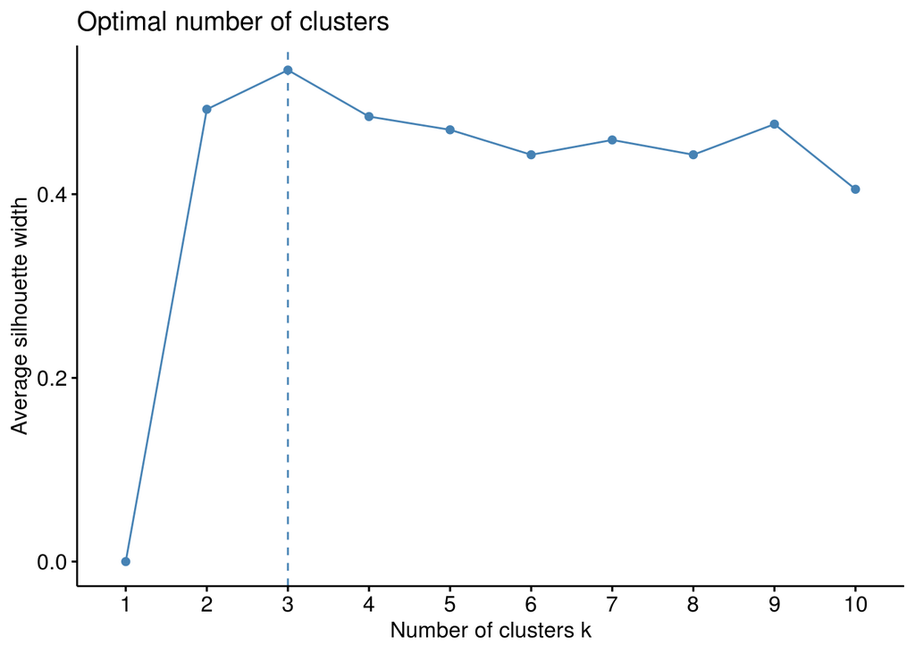

```r
fviz_nbclust(DF, kmeans, method='silhouette')
```

4. The following distance matrix is given. Perform agglomerative hierarchical clustering with *single* und *complete* linkage. Display the result in a dendrogram. The dendrogram should represent the order in which the points are joined.

```r
dm <- tribble(~p1,~p2,~p3,~p4,~p5,
              0.00, 0.02, 0.90, 0.36, 0.53,
              0.02, 0.00, 0.65, 0.15, 0.24,
              0.90, 0.65, 0.00, 0.59, 0.45,
              0.36, 0.15, 0.59, 0.00, 0.56,
              0.53, 0.24, 0.45, 0.56, 0.00) %>% as.matrix()
rownames(dm) <- letters[1:5]
colnames(dm) <- letters[1:5]
knitr::kable(dm)
```

|  | a | b | c | d | e |
| --- | --- | --- | --- | --- | --- |
| a | 0.00 | 0.02 | 0.90 | 0.36 | 0.53 |
| b | 0.02 | 0.00 | 0.65 | 0.15 | 0.24 |
| c | 0.90 | 0.65 | 0.00 | 0.59 | 0.45 |
| d | 0.36 | 0.15 | 0.59 | 0.00 | 0.56 |
| e | 0.53 | 0.24 | 0.45 | 0.56 | 0.00 |

```r
# Solution of task 4...
dm <- as.dist(dm, diag = TRUE)
dm
```

```
##      a    b    c    d    e
## a 0.00
## b 0.02 0.00
## c 0.90 0.65 0.00
## d 0.36 0.15 0.59 0.00
## e 0.53 0.24 0.45 0.56 0.00
```

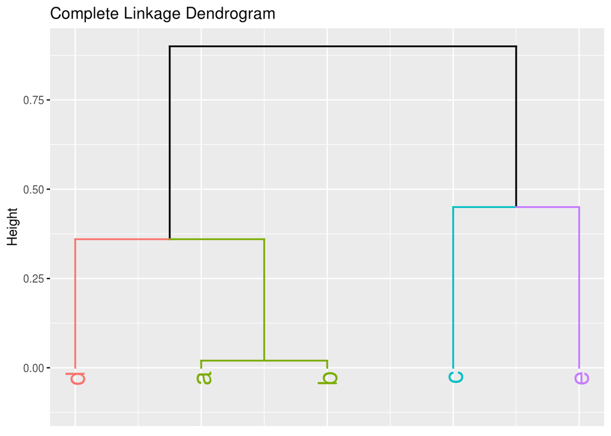

```r
hc <- hclust(dm, method = "complete")
fviz_dend(hc, k = 4,                 # Cut in four groups
          cex = 1.5,                 # label size
          color_labels_by_k = TRUE,
          ggtheme = theme_gray(),
          main = "Complete Linkage Dendrogram"
)
```

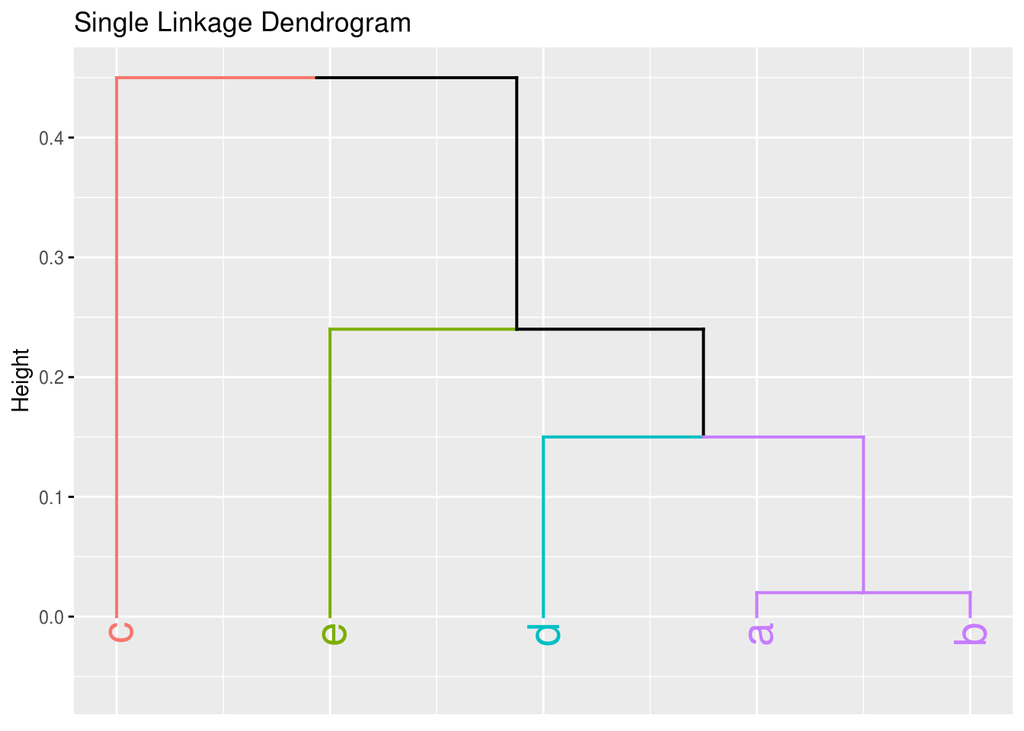

```r
hc <- hclust(dm, method = "single")
fviz_dend(hc, k = 4,                 # Cut in four groups
          cex = 1.5,                 # label size
          color_labels_by_k = TRUE,
          ggtheme = theme_gray(),
          main = "Single Linkage Dendrogram"
)
```

Dataset for task 2:  
http://isgwww.cs.uni-magdeburg.de/cv/lehre/VisAnalytics/material/exercise/datasets/clustering-student-mat.csv